# PNW CRVs

[figure not shown]

Image from [Car and Driver](https://www.caranddriver.com/news/a29688924/2020-honda-cr-v-price/)

## Background

People living in cities in the Pacific Northwest tend to favor smaller more full-efficient vehicles and hybrids because they are more environment-friendly and more budget-friendly for long commutes. Will having less demand mean that people who live where the terrain is more rugged or snowy, or those who like an outdoor lifestyle, can find decent deals on SUVs and crossovers in great condition if they are willing to buy from the PNW?

As part of the second phase of research to purchase a used CRV, data was collected on Honda CRV’s for sale on [Portland’s](https://portland.craigslist.org/search/cto?query=crv) and [Seattle’s](https://seattle.craigslist.org/search/cto?query=crv) Craigslist.

The data was scraped from Craigslist’s Cars and Trucks–by owner, using [ParseHub](https://www.parsehub.com) for Portland on November 3, 2020 and Seattle on November 14, 2020*. All CRVs without price or mileage were removed from the data, as well as, those with rebuilt or salvage titles.

*Parsehub free accounts only allow a user to pull 200 pages of data per month, so the data for Portland which was pulled on the 3rd for the simple linear regression had to be reused. Revisiting the data revealed that some of the CRVs originally pulled from Portland were posted on Seattle’s Craigslist. Those entries were removed from Portland’s data.

Data Table & Notes(click to view)

## Linear Regression Model

To obtain two regression lines, one for CRVs from each region, The multiple linear regression model below was applied to the data from Craigslist.

$$\underbrace{Y_i}_{\text{Price}} = \overbrace{\beta_0 + \beta_1 \underbrace{X_{i1}}_{\text{Mileage}}}^{\text{Portland CRVs}} + \overbrace{\beta_2 \underbrace{X_{i2}}_{\text{Seattle}} + \beta_3 \underbrace{X_{i1} X_{i2}}_{\text{Interaction}}}^{\text{Adjustments to Line for Seattle CRVs}} + \epsilon_i$$

The base intercept for regression line for CRV’s from Portland is $\beta_0$, and the coefficient for the base slope $\beta_1$. The Seattle value times $\beta_2$ is the adjustment to the base y-intecept, and $\beta_3$ times the interaction value is the change in slope. $X_{i2} = 0$ is used when the CRV is from Portland; $X_{i2} = 1$ is used when the CRV is from Seattle. Simplifying the model above according to the $X_{i2}$ value generates models for regression lines for each region:

| CRV Region | Value of $X_{i2}$ | Model |
| --- | --- | --- |
| Portland | $X_{i2} = 0$ | $Y_i = \beta_0 + \beta_1 X_{i1} + \epsilon_i$ |
| Seattle | $X_{i2} = 1$ | $Y_i = (\beta_0 + \beta_2) + (\beta_1 + \beta_3) X_{i1} + \epsilon_i$ |

To compare CRVs from Portland and Seattle, the null hypotheses below will be tested.

### Hypotheses regarding Equal y-Intercepts

If $\beta_2 = 0$, then according to the model, the regression lines have the same y-intercept. However, if $\beta_2$ is not equal to zero, then if the y-intercepts are different.

$$H_0: \beta_2 = 0 \quad \text{(CRVs from Portland and Seattle have the same y-intercept)} \\
H_a: \beta_2 \neq 0 \quad \text{(CRVs from Portland and Seattle have a different y-intercept)}\\
\alpha=0.05$$

### Hypotheses regarding Equal Slopes

If $\beta_3$ equals zero, the slopes of the two lines are the same–the relationship between price and mileage is the same for CRVs from both regions. If $\beta_3$ is not equal to zero, the relationship between price and mileage is not the same for the two regions.

$$H_0: \beta_3 = 0 \quad \text{(CRVs from Portland and Seattle have the same relationship between price and mileage)} \\
H_a: \beta_3 \neq 0 \quad \text{(CRVs from Portland and Seattle have a different price-mileage relationship)}\\
\alpha=0.05$$

## Analysis

The table below contains the summary of the multiple linear regression for the relationship between price and mileage for CRVs by region:

```r
## Code for the multiple linear regression
crv1.lm <- lm(Price ~ Mileage + Region + Mileage:Region, data=crv2)
pander(summary(crv1.lm, caption="Multiple Linear Regression Summary the Relationship Between Price and Mileage by Region"))
```

|  | Estimate | Std. Error | t value | Pr(>\|t\|) |
| --- | --- | --- | --- | --- |
| **(Intercept)** | 20690 | 1190 | 17.38 | 4.605e-21 |
| **Mileage** | -0.07541 | 0.006483 | -11.63 | 7.241e-15 |
| **RegionSeattle** | 1881 | 2022 | 0.9303 | 0.3574 |
| **Mileage:RegionSeattle** | -0.01553 | 0.01135 | -1.367 | 0.1786 |

Fitting linear model: Price ~ Mileage + Region + Mileage:Region

| Observations | Residual Std. Error | $R^2$ | Adjusted $R^2$ |
| --- | --- | --- | --- |
| 47 | 2819 | 0.8433 | 0.8323 |

The summary of the multiple linear regression shows that the region and interaction of mileage and region are insignificant. The p-value for $\beta_2$ and $\beta_3$ are both greater than 0.05.

The scatterplot below shows the regression lines for CRVs from Portland and Seattle.

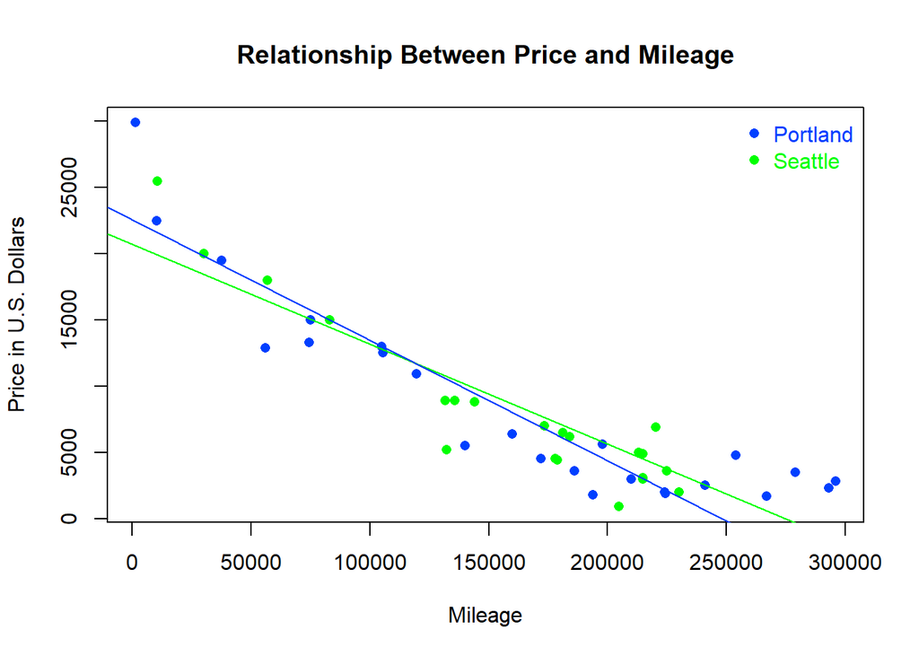

```r
palette(c("#0040ff", "#00ff00"))
plot(Price ~ Mileage, data=crv2, col=Region, main="Relationship Between Price and Mileage", pch=16, ylab="Price in U.S. Dollars")
abline(a= crv1.lm$coefficients[1], b=crv1.lm$coefficients[2], col=palette()[2])
abline(a=crv1.lm$coefficients[1]+crv1.lm$coefficients[3], b=crv1.lm$coefficients[2]+crv1.lm$coefficients[4], col=palette()[1])
legend("topright", col=palette(), pch=16, legend=c("Portland", "Seattle"), bty="n", text.col = palette())
```

### Modifying the Model

```r
crv3.lm <- lm(Price ~ Mileage + Mileage:Region, data=crv2)
pander(summary(crv3.lm, caption="Linear Regression Summary of the Relationship Between Price and Mileage by Region (No Beta 2"))

crv4.lm <- lm(Price ~ Mileage + Region, data=crv2)
pander(summary(crv4.lm, caption="Linear Regression Summary of the Relationship Between Price and Mileage by Region (No Beta 3)"))
```

The linear regression was repeated, first without the Region ($\beta_2$) and then without the interaction term ($\beta_3$). In both cases, the results were insignificant for the remaining term. Removing $\beta_2$ resulted in an interaction term with a $p$-value of 0.2098 and removing $\beta_3$ resulted in Region-Seattle having a $p$-value of 0.4432. To see the code for both regressions, select the `Code` button above.

Finally, the model was simplified by removing the $\beta_2$ and $\beta_3$ terms. In other words, a simple linear regression was performed on the data.

```r
crv2.lm <- lm(Price ~ Mileage, data=crv2)
pander(summary(crv2.lm, caption="Linear Regression Summary of the Relationship Between Price and Mileage by Region"))
```

|  | Estimate | Std. Error | t value | Pr(>\|t\|) |
| --- | --- | --- | --- | --- |
| **(Intercept)** | 21213 | 962 | 22.05 | 9.313e-26 |
| **Mileage** | -0.08051 | 0.00535 | -15.05 | 3.554e-19 |

Fitting linear model: Price ~ Mileage

| Observations | Residual Std. Error | $R^2$ | Adjusted $R^2$ |
| --- | --- | --- | --- |
| 47 | 2834 | 0.8342 | 0.8305 |

Removing the insignificant terms has changed the coefficient values slightly. The p-value of $\beta_1$ < 0.05. The relationship appears to be significant.  
$\hat{Y}_{Price}$ = $21,213 - 0.08{\underbrace{X_{i1}}_{\text{Mileage}}}$

The scatterplot below shows the regression line.

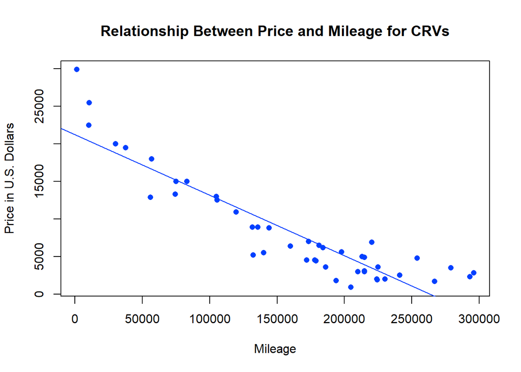

```r
plot(Price ~ Mileage, data=crv2, col="#0040ff", main="Relationship Between Price and Mileage for CRVs", pch=16, ylab="Price in U.S. Dollars")
abline(crv2.lm, col="#0040ff")
```

### Assumptions

The residuals versus fitted values plot shows that the linear relationship assumption was violated as illustrated by the horseshoe shape in the plot while the constant variance assumption looks passable. The residuals plot shows that the data is questionable as several points are outside of the blue dotted lines. There do not appear to be dramatic trends in the residuals on the residuals vs order plot, indicating that the error terms are independent.

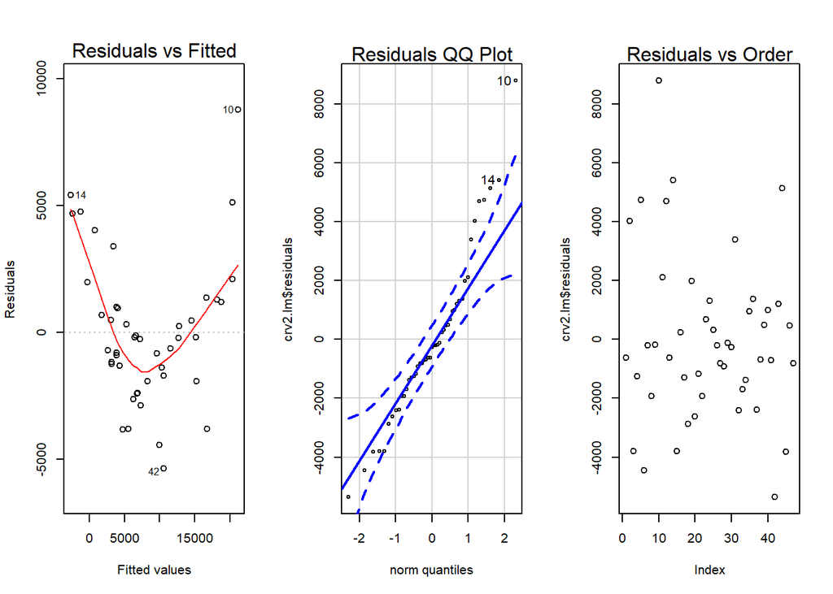

```r
par(mfrow=c(1,3))
plot(crv2.lm, which=1)
qqPlot(crv2.lm$residuals)
mtext(side=3,text="Residuals QQ Plot")
plot(crv2.lm$residuals)
mtext(side=3, text="Residuals vs Order")
```

## Conclusion

For the multiple linear regression, there is insufficient evidence to reject the null for the test of equal y-intercepts and the test of equal slopes as both p-values were greater than 0.05. Prices and depreciation are similar for both regions. Using simple linear regression, there was sufficient evidence to reject the null indicating a linear relationship between mileage and price. However, the assumptions plots indicate that the linear relationship assumption was violated. The tests are unreliable.